# Tarea 5: Monte Carlo

### Alejandro Sánchez Flores - A01662783

```python
import warnings
import numpy as np
import matplotlib.pyplot as plt
from scipy.stats import uniform, expon, norm
```

```python
# ESTILO PARA LAS GRAFICAS
plt.style.use('dark_background')
# SE CREA EL ARRAY DE COLORES
colores = ['#a60d79', '#2fdb4f', '#ffa81a', '#54a3d2' ,'#fdee9b', '#64fcd5', '#dba8d5', '#b4132e', '#1b31c6']
warnings.filterwarnings('ignore')
```

## 1. Considera la función:

$ f(x) = \sin \left( \frac{\frac{\pi}{2}}{1+x^{2n}} \right), ~ x \in \mathbb{R}, ~n\in \mathbb{N} \setminus\{0\} $

```python
# SE DEFINE LA FUNCION
def f(x, n):
    return np.sin((np.pi / 2) / (1 + x**(2*n)))
```

### 1.1 Analiza la familia de funciones

Ya que la función $\sin$ está acotada entre -1 y 1 para cualquier valor de su argumento.

**Rango:** $ sin(0) = 0, sin(\frac{\pi}{2}) = 1 $

La función $g(x) = \frac{\frac{\pi}{2}}{1+x^{2n}}$ es continua sobre $\mathbb{R}$ y como su dominio está definido en todo $\mathbb{R}$, solamente se puede tener un máximo o un mínimo si su derivada se anula.

$g'(x) = - \frac{\pi 2n x^{2n-1}}{\left(1 + x^{2n} \right)^2}$

$\therefore$ $f(x)$ tiene un solo punto extremo en $x=0$.

### 1.2 Grafica de la familia de funciones

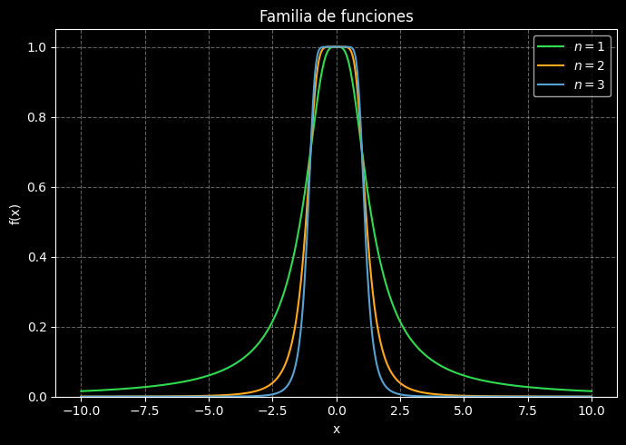

```python
# SE TOMAN LOS VALORES PARA x
x = np.linspace(-10, 10, 1000)

# SE GRAFICAN LOS RESULTADOS
plt.figure(figsize=(7,5))

# PARA CADA TERMINO
for n in range(1, 4):
    plt.plot(x, f(x, n), label=f'$n={n}$', color=colores[n])

plt.xlabel('x')
plt.ylabel('f(x)')
plt.title('Familia de funciones')
plt.grid(True, color='silver', linestyle='--', alpha=0.5)
plt.ylim([0,1.05])
plt.legend()

plt.tight_layout()
plt.show()
```

## 2. Considera la integral:

$ I = \int_{-\infty}^{\infty} f(x)dx $

### 2.1. Analiza la familia de funciones

Ya que $f(x)$ está dada por $f(x) = \sin \left( \frac{\frac{\pi}{2}}{1+x^{2n}} \right)$, podemos utilizar la expansión de Maclaurin de la función $\sin$ alrededor de $x = 0$:

$ \sin(x) = x - \frac{x^3}{3!} + \frac{x^5}{5!} - \frac{x^7}{7!} + \cdots $

Para $|x|$ pequeño, los términos de orden superior son tan pequeños que los podemos ignorar. Entonces, podemos aproximar $f(x)$ como:

$ f(x) \approx \frac{\frac{\pi}{2}}{1+x^{2n}} $

Ahora, analizamos el comportamiento de $\frac{\frac{\pi}{2}}{1+x^{2n}}$ cuando $x$ tiende a $0$:

$ \lim_{x \to 0} \frac{\frac{\pi}{2}}{1+x^{2n}} = \frac{\frac{\pi}{2}}{1+0} = \frac{\pi}{2} $

Como $\frac{\pi}{2}$ es un valor finito, podemos saber que $f(x)$ está acotada cerca de $x = 0$, lo que nos dice que el área bajo la curva de $f(x)$ en el intervalo $[-\infty, \infty]$ puede ser finita.

$\therefore I$ es convergente.

### 2.2. Cálculo de la integral con métodos de Monte Carlo, utilizando diferentes densidades

```python
# FUNCION QUE CALCULA LA INTEGRAL CON METODO DE MONTE CARLO
def integralMC(f, densidad, M, n, nExperimentos):
    ls_aproxs = []

    for _ in range(nExperimentos):
        muestras = densidad.rvs(size=M)

        # MULTIPLICAMOS POR 2 PARA ABARCAR TODO EL RANGO
        aproxIntegral = np.mean(f(muestras, n)) * (2 * muestras.max() - 2 * muestras.min())
        ls_aproxs.append(aproxIntegral)

    return np.array(ls_aproxs)
```

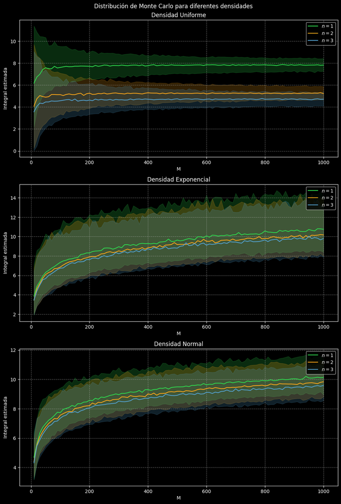

```python
# LISTA DE VALORES DE M
M = np.arange(10, 1001, 10)
# NUMERO DE REPETICIONES EN CADA EXPERIMENTO
nExperimentos = 500
# LISTA DE DENSIDADES PROPUESTAS
ls_densidades = [(uniform(-10, 20), 'Uniforme'), (expon(scale=1), 'Exponencial'), (norm(loc=0, scale=1), 'Normal')]
cont = 1

# SE GRAFICAN LOS RESULTADOS
plt.figure(figsize=(12,16))
plt.suptitle('Distribución de Monte Carlo para diferentes densidades')

# SE CACLCULA LAS INTEGRALES POR METODO DE MONTE CARLO
for dens, densNombre in ls_densidades:
    plt.subplot(3, 1, cont)

    for n in range(1, 4):
        integrales = [integralMC(f, dens, m, n, nExperimentos) for m in M]
        media = np.median(integrales, axis=1)
        max = np.percentile(integrales, 5, axis=1)
        min = np.percentile(integrales, 95, axis=1)

        plt.fill_between(M, max, min, color=colores[n], alpha=0.2)
        plt.plot(M, media, color=colores[n], label=f'$n={n}$')

    cont += 1
    plt.title(f'Densidad {densNombre}')
    plt.xlabel('M')
    plt.ylabel('Integral estimada')
    plt.grid(True, color='silver', linestyle='--', alpha=0.5)
    plt.legend()

plt.subplots_adjust(top=0.95, bottom=0.1)
plt.show()
```

### 2.3. Distribución de Monte Carlo para una nueva densidad propuesta para la función de la familia $n=2$

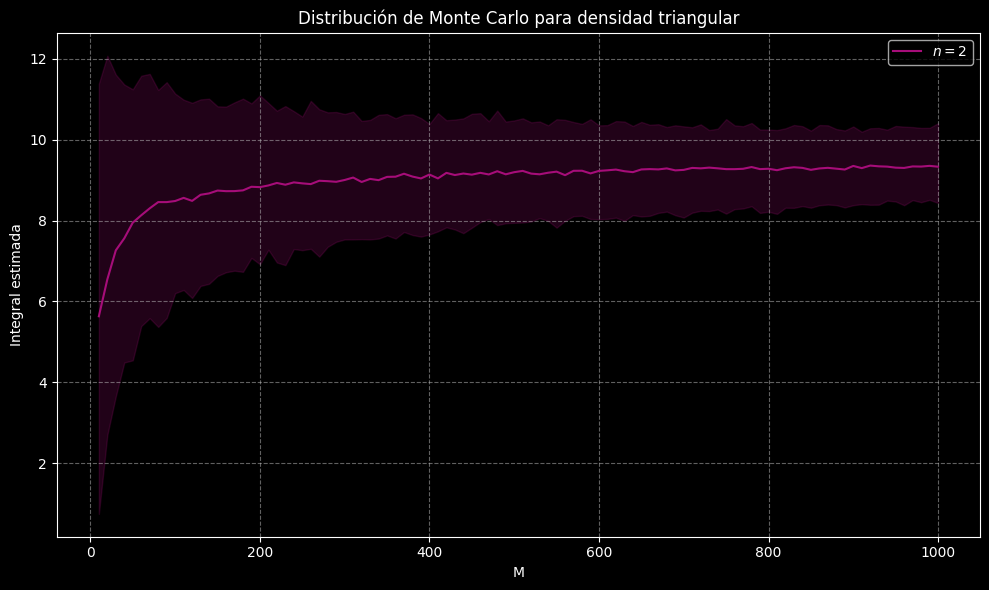

```python
# SELECCIONO LA DENSIDAD TRIANGULAR
from scipy.stats import triang

# SE GRAFICAN LOS RESULTADOS
plt.figure(figsize=(10, 6))

integrales = [integralMC(f, triang(c=0.5, loc=-10, scale=20), m, 2, nExperimentos) for m in M]
media = np.median(integrales, axis=1)
max = np.percentile(integrales, 2.5, axis=1)
min = np.percentile(integrales, 97.5, axis=1)

plt.fill_between(M, max, min, color=colores[0], alpha=0.2)
plt.plot(M, media, color=colores[0], label=f'$n={2}$')

plt.title(f'Distribución de Monte Carlo para densidad triangular')
plt.xlabel('M')
plt.ylabel('Integral estimada')
plt.grid(True, color='silver', linestyle='--', alpha=0.5)
plt.legend()

plt.tight_layout()
plt.show()
```

## 3. Ahora considera la función:

$ g(x,y) \sin \left(\frac{\pi}{2 \left(1 + x^2 + y^2 \right)} \right) $

```python
# SE DEFINE LA FUNCION
def g(x, y):
    return np.sin(np.pi / (2 * (1 + x**2 + y**2)))

# FUNCION QUE CALCULA EL VOLUMEN BAJO LA FUNCION g(x, y) UTILIZANDO EL METODO DE MONTE CARLO
def volumenMC(f, densidad, M, nExperimentos):
    ls_volumenes = []

    for m in M:
        ls_aproxs = []

        for _ in range(nExperimentos):
            muestraX = densidad.rvs(size=m)
            muestraY = densidad.rvs(size=m)
            muestraZ = f(muestraX, muestraY)

            # MULTIPLICAMOS POR EL AREA DEL CUADRADRO
            aprox = np.mean(muestraZ) * (20**2)
            ls_aproxs.append(aprox)

        ls_volumenes.append(ls_aproxs)

    return np.array(ls_volumenes)
```

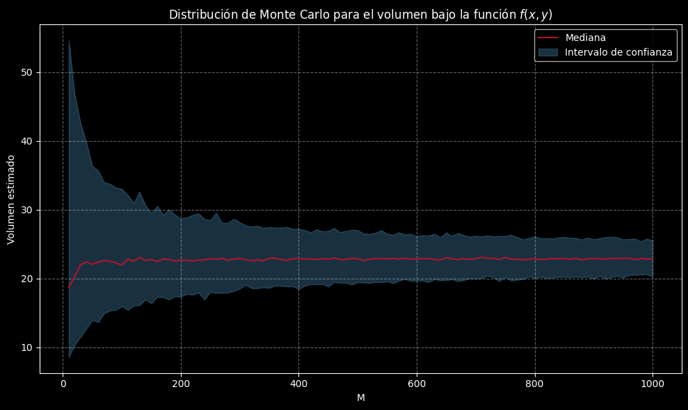

```python
# RANGO DE VALORES DE M
M = np.arange(10, 1010, 10)
# SE CALCULA EL VOLUMEN CON DISTRIBUCION MONTE CARLO USANDO DISTRIBUCION UNIFORME
volumen = volumenMC(g, uniform(loc=-10, scale=20), M, 500)
# CALCULAMOS LOS CUARTILES Y MEDIA DE LA DISTRIBUCION MONTE CARLO
max = np.percentile(volumen, 2.5, axis=1)
min = np.percentile(volumen, 97.5, axis=1)
media = np.median(volumen, axis=1)

# GRAFICAMOS LOS RESULTADOS DE LA DISTRIBUCION
plt.figure(figsize=(10, 6))
plt.plot(M, media, color=colores[7], label='Mediana')
plt.fill_between(M, max, min, alpha=0.3, color=colores[3],label='Intervalo de confianza')
plt.title('Distribución de Monte Carlo para el volumen bajo la función $f(x,y)$')
plt.xlabel('M')
plt.ylabel('Volumen estimado')
plt.grid(True, color='silver', linestyle='--', alpha=0.5)
plt.legend()
plt.tight_layout()
plt.show()
```